# Computational graph of our small network

We have so far seen how inputs are combined with weight matrices to produce the output of a layer. How it can be passed through activation functions to squash it to desired range. However, to fully appreciate the complexity or intricacies of the things that go underneath, it is often better to visualize them. Now, there are a ton of vizs out there but I think this one ticks all the checkboxes for me. Thanks to Anand Avati from Prof Ng's lab at Stanford.

Note that we have not used any activation in output layer i.e there is no $a^{[2]}$ and only $z^{[2]}$ exists. This is because we are using this network to predict y (which is real valued and take any value). Because, if we use something such as a sigmoid in the output layer it squishes everything to between $0$ and $1$. We could have used ReLU but to keep things simple I have avoided it.

The image is pretty self-explanatory so I won't describe it here.

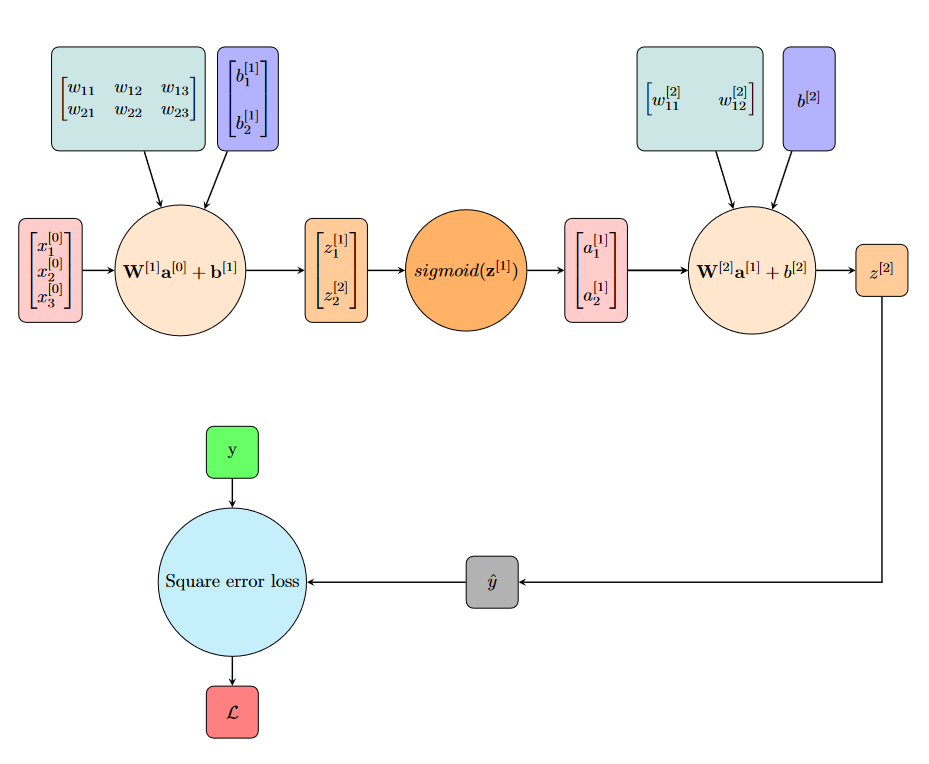

# Neural networks as functions

This is the math that I had been hiding from you until now. It is not that scary if you seen some symbols before. It is quite intuitive if you already know the intuition behind derivatives, gradients, and composite functions. However, I have tried my best to make it more text and less math. Read all $f()$ as "function of" as loudly in your mind or aloud. It helps. Also, I have sigmoid function below and it is purely by choice. Same theory applies for all activation functions.

All bold small letters are vectors, bold capital letters are matrices, and small letters are scalars

$$\mathcal{L}(Loss) = f(\text{output of neural network, actual output}) = f(\mathbf{\hat{y}}, \mathbf{y})$$

In general, for the $L^{th}$ layer,

$$\text{Activations or } \mathbf{a}^{[L]} = \mathbf{\hat{y}} = \sigma(\mathbf{z}^{[L]}) = \frac{1}{1 + e^{-\mathbf{z}^{[L]}}}$$

$$\mathbf{z}^{[L]} = f(\mathbf{W}^{[L]}, \mathbf{a}^{[L-1]}, \mathbf{b}^{[L]})$$

$$\mathbf{z}^{[L]} = \mathbf{W}^{[L]}\mathbf{a}^{[L-1]} + \mathbf{b}^{[L]}$$

$\newline$

We expand the terms $\mathbf{W}^{[L]}$ and $\mathbf{a}^{[L-1]}$ below,

$\newline$ $$\mathbf{a}^{[L-1]} = \big(a_{1}^{[L-1]}, a_{2}^{[L-1]}, .., a_{k}^{[L-1]}\big)$$

$\newline$

$$\mathbf{W}^{[L]} = \begin{bmatrix}w_{11}^{[L]}&w_{12}^{[L]}&.&.&w_{1k}^{[L]}\\ w_{21}^{[L]}&w_{22}^{[L]}&.&.&w_{2k}^{[L]}\\ .&\\ .&\\ w_{j1}^{[L]}&w_{j2}^{[L]}&.&.&w_{jk}^{[L]}\end{bmatrix}$$

$\newline$

$$\mathbf{z}^{[L]} = \big(z_{1}^{[L]}, z_{2}^{[L]}, . ., z_{k}^{[L]}\big)$$

$\newline$

Notice the nested nature of outputs. Composite functions. For the output layer $L$, we can write,

$$\mathcal{Loss} = f(\mathbf{\hat{y}}) = f(\color{red}{f(\mathbf{a}^{[L]})}) = f(\color{red}{f(}\color{blue}{f(\mathbf{z}^{[L]})}\color{red})) = f(\color{red}{f(}\color{blue}{f(}\color{green}{f(\mathbf{a}^{[L-1]}, \mathbf{W}^{[L]}, \mathbf{b}^{[L]})}\color{blue}{)}\color{red}))$$

At first look, it is daunting. Notice the color coding. Forget everything about what is inside those functions. The idea is this: black function is a function of red function, which is a function of the blue function, which in turn is a function of the green function. Simple right? Now put back the formula for calculating $\mathcal{L}(loss)$, $\mathbf{z}$, and $\mathbf{a}$

Trust me, this single realization is extremly helpful and powerful to understand the process of training and how gradients are computed using chain rule. This also helps to appreciate the power of chain rule when evaluating gradients of such complex functions.

BUT, it does not end here. Take the nested equation above and try to go back one more layer! Hurts your head right? But work it out. Try for $(L-1)$ which will involve activations from $(L-2)$. As you go back layer by layer the nested-ness becomes more and more crazy and at the end you have a highly nested function. So, neural networks are nothing but composite functions, a very ugly one at that!